# R Notebook

# Set-up

```r
library(tidyverse)
```

# Import CSV

```r
csv_files <- list.files('~/Box/R01 Project 2 Data for Yiming&Rick/R01A-C files for transitional probabilities', pattern = '\\.csv$', full.names = TRUE, )
csv_files
```

```
[1] "/Users/rog1/Box/R01 Project 2 Data for Yiming&Rick/R01A-C files for transitional probabilities/freq_start.csv"
[2] "/Users/rog1/Box/R01 Project 2 Data for Yiming&Rick/R01A-C files for transitional probabilities/R01_A_Data_Export_DS_newAOInames.csv"
```

```r
df <- readr::read_csv(csv_files[2])
```

# Data cleaning

Let’s parse and reformat the column names.

```r
df_new <- df %>%
  purrr::set_names(~ str_to_lower(.) %>%
                     str_replace_all("AOI|aoi", "") %>%
                     str_replace_all("\\[", ""))
```

Let’s then select one participant.

```r
p_ids <- unique(df_new$participantname)
p_ids
```

```
[1] "TR"      "BF"      "CB_SV"   "HGR_UP2" "AHV_UP"
```

Let’s pick the first one.

```r
df_TR <- df_new[df_new$participantname == "TR",]
```

I need to write a function to sequentially pull unique values.

```r
extract_media_value_sequence <- function(x) {
  not_nas <- !(is.na(x))
  these_xs <- NULL
  prior_x <- ""
  x_clean <- x[not_nas]
  for (i in 1:length(x_clean)) {
    this_x <- x_clean[i]
    if (!is.na(this_x)) {
      if (this_x != prior_x) {
        these_xs <- c(these_xs, this_x)
      }
      prior_x <- this_x
    }
  }
  these_xs
}
```

## Display conditions

Make a data frame with the condition information. This requires parsing the `medianame` for the samples that show the array (have extention `.png`) and the samples that show the prompt (have extension `.wmv`).

```r
df_TR_disp_only <- df_TR %>%
  dplyr::select(., recordingtimestamp, medianame) %>%
  dplyr::filter(., str_detect(medianame, 'White|Color')) %>%
  dplyr::arrange(., recordingtimestamp)

conditions_df <-
  tibble(medianame = extract_media_value_sequence(df_TR_disp_only$medianame))

conditions_df$trial <- 1:dim(conditions_df)[1]

layout_pattern <- "(Color|White)_(SOC|wide|corners|[Cc]lock)"
bgnd_layout <- str_match(conditions_df$medianame, layout_pattern)

conditions_df <- conditions_df %>%
  mutate(., bgnd = bgnd_layout[,2],
         layout = bgnd_layout[,3])

# Now prompts
df_TR_prompt_only <- df_TR %>%
  dplyr::select(., recordingtimestamp, medianame) %>%
  dplyr::filter(., !is.na(medianame),
                str_detect(medianame, 'wmv')) %>%
  dplyr::arrange(., recordingtimestamp)


prompts_df <- tibble(medianame = extract_media_value_sequence(df_TR_prompt_only$medianame))
prompts_df$trial <- 1:dim(prompts_df)[1]

media_nm_pattern <- "([A-Z]{1}[a-z]+)_([a-z]+)"
spkr_target <- str_match(prompts_df$medianame, media_nm_pattern)

prompts_df <- prompts_df %>%
  mutate(., speaker = spkr_target[,2],
         target = spkr_target[,3])

# drop medianame since prompt has its own medianame value

prompts_df <- prompts_df %>%
  dplyr::select(., -medianame)

stims_df <- dplyr::left_join(conditions_df, prompts_df, by = c('trial'))
str(stims_df)
```

```
tibble [1,635 × 6] (S3: tbl_df/tbl/data.frame)
 $ medianame: chr [1:1635] "Color_wide.png" "White_wide.png" "Color_wide.png" "White_wide.png" ...
 $ trial    : int [1:1635] 1 2 3 4 5 6 7 8 9 10 ...
 $ bgnd     : chr [1:1635] "Color" "White" "Color" "White" ...
 $ layout   : chr [1:1635] "wide" "wide" "wide" "wide" ...
 $ speaker  : chr [1:1635] "Paul" "Mary" "Paul" "Mary" ...
 $ target   : chr [1:1635] "me" "hot" "me" "hot" ...
```

## Process button presses

We need to determine when the trials end.

It looks like the relevant events have a mousevent and a medianame with ‘Color|White’ in the title.

```r
df_mouse <- df_TR %>%
  dplyr::select(., medianame, recordingtimestamp, mouseeventindex,  mouseevent) %>%
  dplyr::filter(., !is.na(mouseevent),
                str_detect(medianame, 'White|Color')) %>%
  dplyr::mutate(., elapsed_secs = recordingtimestamp/1000)
str(df_mouse)
```

```
tibble [64 × 5] (S3: tbl_df/tbl/data.frame)
 $ medianame         : chr [1:64] "White_wide.png" "White_SOC.png" "White_clock.png" "White_wide_2.png" ...
 $ recordingtimestamp: num [1:64] 12500 21619 30539 37755 51035 ...
 $ mouseeventindex   : num [1:64] 2 3 4 5 6 7 8 9 10 11 ...
 $ mouseevent        : chr [1:64] "Left" "Left" "Left" "Left" ...
 $ elapsed_secs      : num [1:64] 12.5 21.6 30.5 37.8 51 ...
```

Let’s plot just for fun.

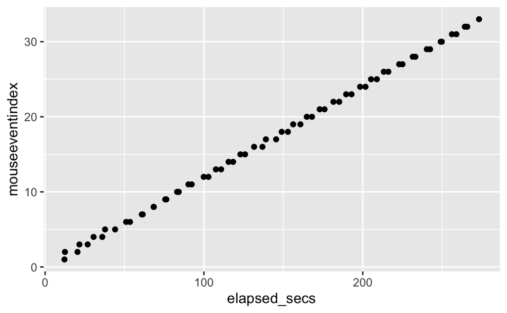

```r
df_mouse %>%
  ggplot(.) +
  aes(elapsed_secs, mouseeventindex) +
  geom_point()
```

Ok, so there are 64 mouse events. Why am I getting only 32 trials in the AOIs?

## Process AOI information

Take wide columns and make longer.

```r
df_TR_longer <- df_TR %>%
  pivot_longer(
    cols = `1c-wide-swing]hit`:`32x-wide-all]hit_1`,
    names_pattern = "([0-9]+)([abcx])\\-([a-z]+)\\-([a-z\\-123]+)]hit_?(1?)",
    names_to = c("aoi_trial_index", "category", "layout", "aoi", "fix_here"),
    values_to = "count"
  )
```

Trim some columns.

```r
df_TR_trim <- df_TR_longer %>%
  dplyr::select(., -studioprojectname,
                -studiotestname,
                -`participant type]value`,
                -mouseeventindex,
                -mouseevent,
                -`mouseeventx (adcspx)`,
                -`mouseeventy (adcspx)`,
                -`mouseeventx (mcspx)`,
                -`mouseeventy (mcspx)`,
                -gazeeventtype,
                -`fixationpointx (mcspx)`,
                -`fixationpointy (mcspx)`) %>%
  dplyr::filter(., !is.na(medianame),
                str_detect(medianame, 'White|Color'),
                !is.na(count)) %>%
  dplyr::arrange(., fixationindex, recordingtimestamp)
```

## Fixations during display period

Ok, back to the fixations.

```r
df_TR_trim <- df_TR_trim %>%
  dplyr::filter(., category %in% c('a', 'b', 'c')) %>%
  # convert trial to integer
  dplyr::mutate(., aoi_trial_index = as.numeric(aoi_trial_index),
                secs = recordingtimestamp/1000) %>%
  dplyr::select(., -recordingtimestamp) %>%
  dplyr::arrange(., secs)

dim(df_TR_trim)
```

```
[1] 145984     11
```

Do some work to eliminate the rows that show both a fixation to one of the target categories (a, b, or c) AND to anywhere on the screen (whitespace) or x.

```r
n_aois_per <- df_TR_trim %>%
  dplyr::arrange(., fixationindex, secs) %>%
  dplyr::group_by(., secs) %>%
  dplyr::summarize(., n_aois = cumsum(count))
#these_aois <- (n_aois_per$n_aois == 1)

df_TR_trim <- df_TR_trim %>%
  dplyr::arrange(., fixationindex, secs)

df_merge <- df_TR_trim %>%
  dplyr::mutate(., n_aois_per_fix = n_aois_per$n_aois) %>%
  dplyr::filter(., n_aois_per_fix == 1) %>%
  dplyr::arrange(., secs) %>%
  dplyr::filter(., count == 1)
```

# Plot one participant and one trial

How many trials?

```r
df_merge$aoi_trial_index
```

[output not shown]

Looks like there are 32.

## Trial 1

Select fixations for trial 1.

```r
this_trial <- df_merge %>%
  filter(., aoi_trial_index == 1)
```

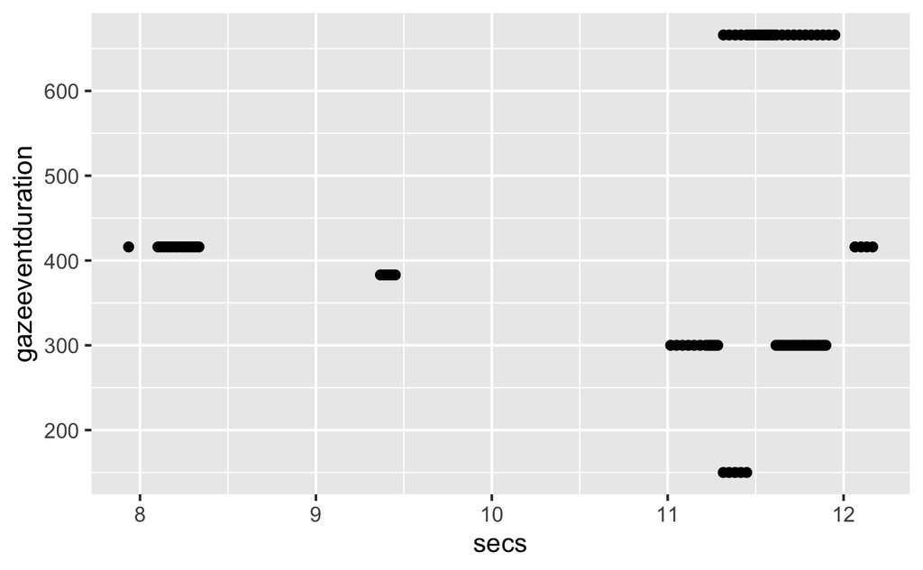

```r
this_trial %>%
  ggplot(.) +
  aes(x=secs, y=gazeeventduration) +
  geom_point()
```

Let’s generate cumulative sums.

```r
this_trial_fixations <- this_trial %>%
  dplyr::filter(., count == 1) %>%
  dplyr::group_by(., category, fixationindex) %>%
  dplyr::summarize(., fix_ms = mean(gazeeventduration),
                   fix_start = min(secs),
                   fix_end = max(secs)) %>%
  dplyr::arrange(., fixationindex)
this_trial_fixations_cum_sum <- this_trial_fixations %>%
  dplyr::group_by(., category) %>%
  dplyr::summarize(., fixationindex = fixationindex,
                   cum_fix = cumsum(fix_ms),
                   fix_start = fix_start,
                   fix_end = fix_end) %>%
  dplyr::arrange(., fixationindex, fix_start)
start_cum_sum <- c(0, this_trial_fixations_cum_sum$cum_fix[1:length(this_trial_fixations_cum_sum)-1])

xx <- this_trial_fixations_cum_sum %>%
  tidyr::pivot_longer(., c(fix_start, fix_end), names_to = "fix_evt", values_to = "ms") %>%
  dplyr::arrange(., fixationindex, ms)

yy <- this_trial_fixations_cum_sum %>%
  dplyr::select(., fixationindex, cum_fix) %>%
  dplyr::mutate(., cum_fix_start = c(0, cum_fix[1:length(cum_fix)-1])) %>%
  tidyr::pivot_longer(., c(cum_fix_start, cum_fix), names_to = "sum_cat", values_to = "cum_sum_ms") %>%
  dplyr::arrange(., fixationindex, cum_sum_ms)
zz <- xx
zz$cum_sum_ms = yy$cum_sum_ms
```

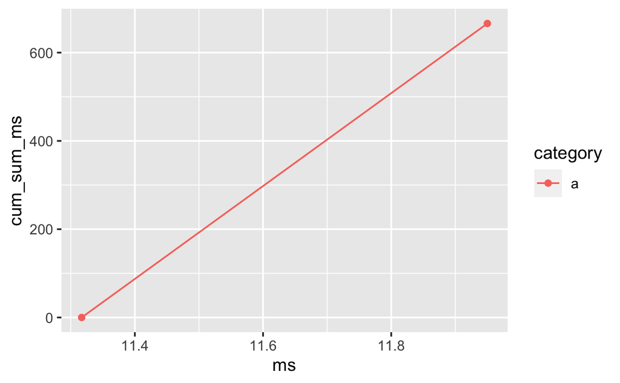

```r
zz %>%
  dplyr::arrange(., category, fixationindex) %>%
  filter(., category == 'a') %>%
  ggplot(.) +
  aes(x = ms, y = cum_sum_ms, color = category) +
  geom_point() +
  geom_line()
```

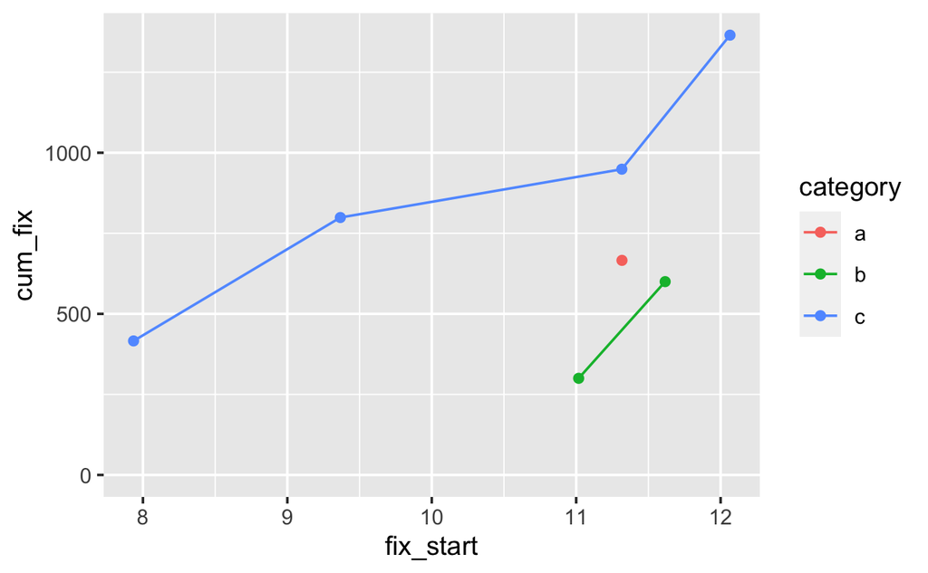

```r
this_trial_fixations_cum_sum %>%
  ggplot(.) +
  aes(x = fix_start, y = cum_fix, color = category) +
  geom_point() +
  geom_line() +
  ylim(0,max(this_trial_fixations_cum_sum$cum_fix))
```

## Trial 2

Select fixations for trial 2.

```r
this_trial <- df_merge %>%
  filter(., aoi_trial_index == 2)
```

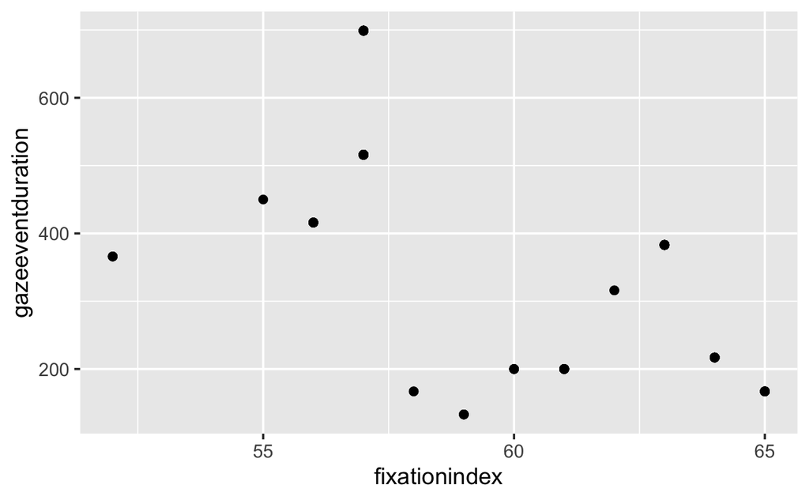

```r
this_trial %>%
  ggplot(.) +
  aes(x=fixationindex, y=gazeeventduration) +
  geom_point()
```

Let’s generate cumulative sums.

```r
this_trial_fixations <- this_trial %>%
  dplyr::filter(., count == 1) %>%
  dplyr::group_by(., category, fixationindex) %>%
  dplyr::summarize(., fix_ms = mean(gazeeventduration),
                   fix_start = min(secs),
                   fix_end = max(secs)) %>%
  dplyr::arrange(., fixationindex)
this_trial_fixations_cum_sum <- this_trial_fixations %>%
  dplyr::group_by(., category) %>%
  dplyr::summarize(., fixationindex = fixationindex,
                   cum_fix = cumsum(fix_ms),
                   fix_start = fix_start,
                   fix_end = fix_end) %>%
  dplyr::arrange(., fixationindex, fix_start)
start_cum_sum <- c(0, this_trial_fixations_cum_sum$cum_fix[1:length(this_trial_fixations_cum_sum)-1])

xx <- this_trial_fixations_cum_sum %>%
  tidyr::pivot_longer(., c(fix_start, fix_end), names_to = "fix_evt", values_to = "ms") %>%
  dplyr::arrange(., fixationindex, ms)

yy <- this_trial_fixations_cum_sum %>%
  dplyr::select(., fixationindex, cum_fix) %>%
  dplyr::mutate(., cum_fix_start = c(0, cum_fix[1:length(cum_fix)-1])) %>%
  tidyr::pivot_longer(., c(cum_fix_start, cum_fix), names_to = "sum_cat", values_to = "cum_sum_ms") %>%
  dplyr::arrange(., fixationindex, cum_sum_ms)
zz <- xx
zz$cum_sum_ms = yy$cum_sum_ms
```

```r
zz %>%
  dplyr::arrange(., category, fixationindex) %>%
#  filter(., category == 'a') %>%
  ggplot(.) +
  aes(x = ms, y = cum_sum_ms, color = category) +
  geom_point() +
  geom_line()
```

[output not shown]

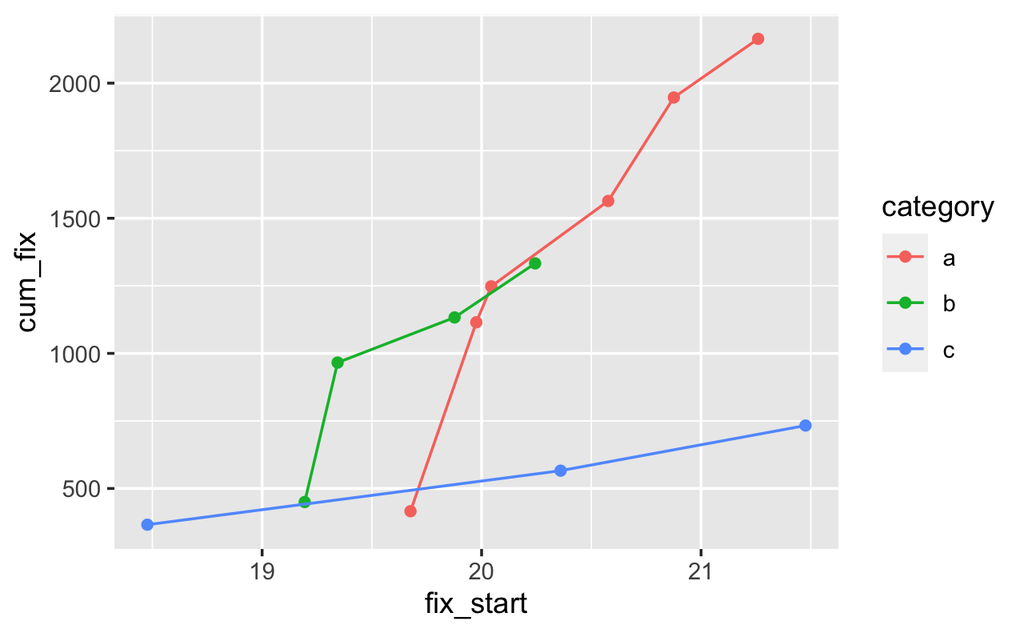

```r
this_trial_fixations_cum_sum %>%
  ggplot(.) +
  aes(x = fix_start, y = cum_fix, color = category) +
  geom_point() +
  geom_line()
```

```r
this_trial <- df_merge %>%
  filter(., aoi_trial_index == 28)
```

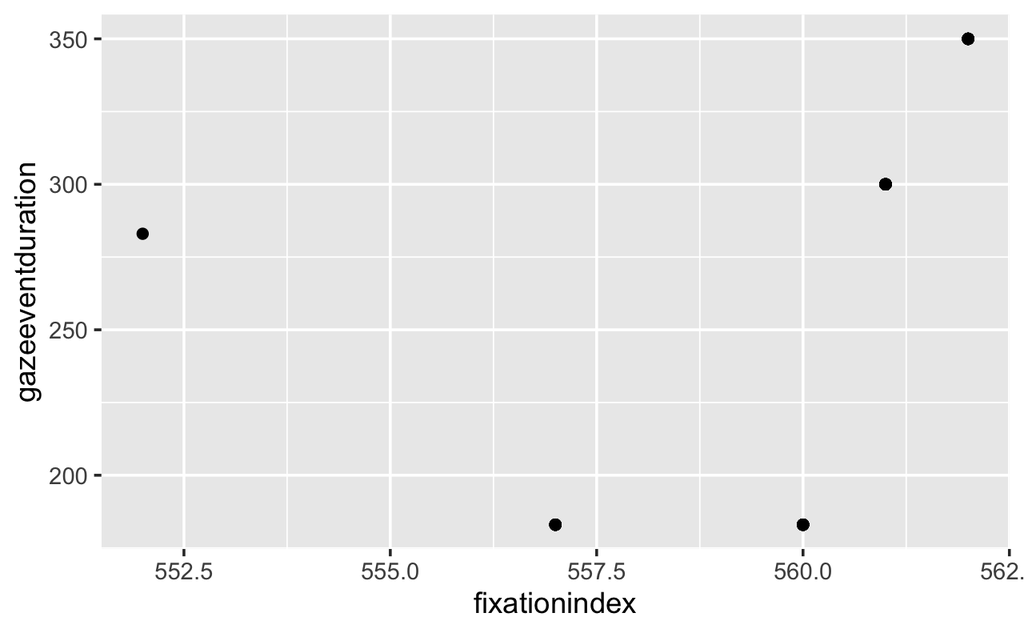

```r
this_trial %>%
  ggplot(.) +
  aes(x=fixationindex, y=gazeeventduration) +
  geom_point()
```

Let’s generate cumulative sums.

```r
this_trial_fixations <- this_trial %>%
  dplyr::filter(., count == 1) %>%
  dplyr::group_by(., category, fixationindex) %>%
  dplyr::summarize(., fix_ms = mean(gazeeventduration),
                   fix_start = min(secs),
                   fix_end = max(secs)) %>%
  dplyr::arrange(., fixationindex)
this_trial_fixations_cum_sum <- this_trial_fixations %>%
  dplyr::group_by(., category) %>%
  dplyr::summarize(., fixationindex = fixationindex,
                   cum_fix = cumsum(fix_ms),
                   fix_start = fix_start,
                   fix_end = fix_end) %>%
  dplyr::arrange(., fixationindex, fix_start)
start_cum_sum <- c(0, this_trial_fixations_cum_sum$cum_fix[1:length(this_trial_fixations_cum_sum)-1])

xx <- this_trial_fixations_cum_sum %>%
  tidyr::pivot_longer(., c(fix_start, fix_end), names_to = "fix_evt", values_to = "ms") %>%
  dplyr::arrange(., fixationindex, ms)

yy <- this_trial_fixations_cum_sum %>%
  dplyr::select(., fixationindex, cum_fix) %>%
  dplyr::mutate(., cum_fix_start = c(0, cum_fix[1:length(cum_fix)-1])) %>%
  tidyr::pivot_longer(., c(cum_fix_start, cum_fix), names_to = "sum_cat", values_to = "cum_sum_ms") %>%
  dplyr::arrange(., fixationindex, cum_sum_ms)
zz <- xx
zz$cum_sum_ms = yy$cum_sum_ms
```

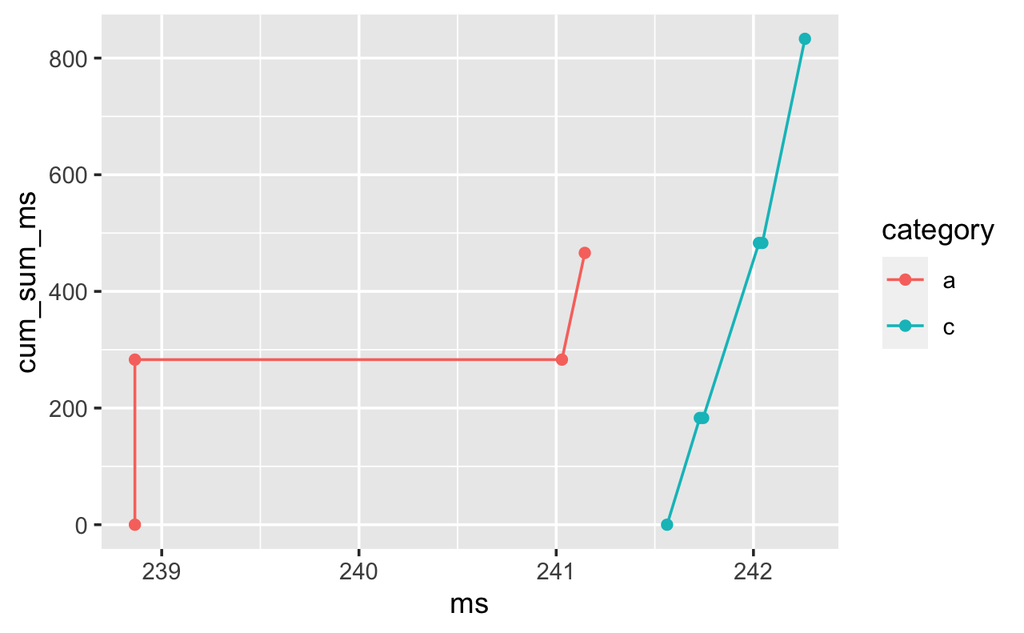

```r
zz %>%
  dplyr::arrange(., category, fixationindex) %>%
  #filter(., category == 'a') %>%
  ggplot(.) +
  aes(x = ms, y = cum_sum_ms, color = category) +
  geom_point() +
  geom_line()
```

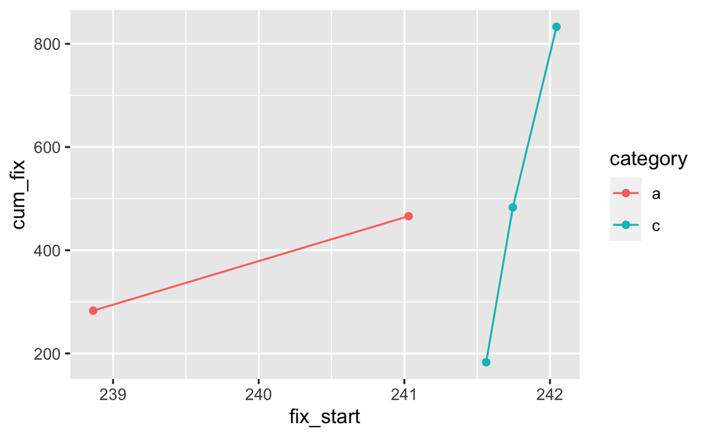

```r
this_trial_fixations_cum_sum %>%
  ggplot(.) +
  aes(x = fix_start, y = cum_fix, color = category) +
  geom_point() +
  geom_line()
```

## Trial 4

```r
this_trial <- df_merge %>%
  filter(., trial == 4)
```

```r
this_trial %>%
  ggplot(.) +
  aes(x=fixationindex, y=gazeeventduration) +
  geom_point()
```

[output not shown]

Let’s generate cumulative sums.

```r
this_trial_fixations <- this_trial %>%
  dplyr::filter(., count == 1) %>%
  dplyr::group_by(., category, fixationindex) %>%
  dplyr::summarize(., fix_ms = mean(gazeeventduration),
                   fix_start = min(recordingtimestamp),
                   fix_end = max(recordingtimestamp)) %>%
  dplyr::arrange(., fixationindex)

this_trial_fixations_cum_sum <- this_trial_fixations %>%
  dplyr::group_by(., category) %>%
  dplyr::summarize(., fixationindex = fixationindex,
                   cum_fix = cumsum(fix_ms),
                   fix_start = fix_start,
                   fix_end = fix_end) %>%
  dplyr::arrange(., fixationindex, fix_start)

start_cum_sum <- c(0, this_trial_fixations_cum_sum$cum_fix[1:length(this_trial_fixations_cum_sum)-1])

xx <- this_trial_fixations_cum_sum %>%
  tidyr::pivot_longer(., c(fix_start, fix_end), names_to = "fix_evt", values_to = "ms") %>%
  dplyr::arrange(., fixationindex, ms)

yy <- this_trial_fixations_cum_sum %>%
  dplyr::select(., fixationindex, cum_fix) %>%
  dplyr::mutate(., cum_fix_start = c(0, cum_fix[1:length(cum_fix)-1])) %>%
  tidyr::pivot_longer(., c(cum_fix_start, cum_fix), names_to = "sum_cat", values_to = "cum_sum_ms") %>%
  dplyr::arrange(., fixationindex, cum_sum_ms)

zz <- xx
zz$cum_sum_ms = yy$cum_sum_ms
```

```r
zz %>%
  dplyr::arrange(., category, fixationindex) %>%
  #filter(., category == 'a') %>%
  ggplot(.) +
  aes(x = ms, y = cum_sum_ms, color = category) +
  geom_point() +
  geom_line()
```

[output not shown]

```r
this_trial_fixations_cum_sum %>%
  ggplot(.) +
  aes(x = fix_start, y = cum_fix, color = category) +
  geom_point() +
  geom_line()
```

[output not shown]

## Trial 5

Select fixations for trial 5.

```r
this_trial <- df_merge %>%
  filter(., trial == 5)
```

```r
this_trial %>%
  ggplot(.) +
  aes(x=fixationindex, y=gazeeventduration) +
  geom_point()
```

[output not shown]

Let’s generate cumulative sums.

```r
this_trial_fixations <- this_trial %>%
  dplyr::filter(., count == 1) %>%
  dplyr::group_by(., category, fixationindex) %>%
  dplyr::summarize(., fix_ms = mean(gazeeventduration),
                   fix_start = min(recordingtimestamp),
                   fix_end = max(recordingtimestamp)) %>%
  dplyr::arrange(., fixationindex)

this_trial_fixations_cum_sum <- this_trial_fixations %>%
  dplyr::group_by(., category) %>%
  dplyr::summarize(., fixationindex = fixationindex,
                   cum_fix = cumsum(fix_ms),
                   fix_start = fix_start,
                   fix_end = fix_end) %>%
  dplyr::arrange(., fixationindex, fix_start)

start_cum_sum <- c(0, this_trial_fixations_cum_sum$cum_fix[1:length(this_trial_fixations_cum_sum)-1])

xx <- this_trial_fixations_cum_sum %>%
  tidyr::pivot_longer(., c(fix_start, fix_end), names_to = "fix_evt", values_to = "ms") %>%
  dplyr::arrange(., fixationindex, ms)

yy <- this_trial_fixations_cum_sum %>%
  dplyr::select(., fixationindex, cum_fix) %>%
  dplyr::mutate(., cum_fix_start = c(0, cum_fix[1:length(cum_fix)-1])) %>%
  tidyr::pivot_longer(., c(cum_fix_start, cum_fix), names_to = "sum_cat", values_to = "cum_sum_ms") %>%
  dplyr::arrange(., fixationindex, cum_sum_ms)

zz <- xx
zz$cum_sum_ms = yy$cum_sum_ms
```

```r
zz %>%
  dplyr::arrange(., category, fixationindex) %>%
  #filter(., category == 'a') %>%
  ggplot(.) +
  aes(x = ms, y = cum_sum_ms, color = category) +
  geom_point() +
  geom_line()
```

[output not shown]

```r
this_trial_fixations_cum_sum %>%
  ggplot(.) +
  aes(x = fix_start, y = cum_fix, color = category) +
  geom_point() +
  geom_line()
```

[output not shown]

## Trial 6

```r
this_trial <- df_merge %>%
  filter(., trial == 6)
```

```r
this_trial %>%
  ggplot(.) +
  aes(x=fixationindex, y=gazeeventduration) +
  geom_point()
```

[output not shown]

Let’s generate cumulative sums.

```r
this_trial_fixations <- this_trial %>%
  dplyr::filter(., count == 1) %>%
  dplyr::group_by(., category, fixationindex) %>%
  dplyr::summarize(., fix_ms = mean(gazeeventduration),
                   fix_start = min(recordingtimestamp),
                   fix_end = max(recordingtimestamp)) %>%
  dplyr::arrange(., fixationindex)

this_trial_fixations_cum_sum <- this_trial_fixations %>%
  dplyr::group_by(., category) %>%
  dplyr::summarize(., fixationindex = fixationindex,
                   cum_fix = cumsum(fix_ms),
                   fix_start = fix_start,
                   fix_end = fix_end) %>%
  dplyr::arrange(., fixationindex, fix_start)

start_cum_sum <- c(0, this_trial_fixations_cum_sum$cum_fix[1:length(this_trial_fixations_cum_sum)-1])

xx <- this_trial_fixations_cum_sum %>%
  tidyr::pivot_longer(., c(fix_start, fix_end), names_to = "fix_evt", values_to = "ms") %>%
  dplyr::arrange(., fixationindex, ms)

yy <- this_trial_fixations_cum_sum %>%
  dplyr::select(., fixationindex, cum_fix) %>%
  dplyr::mutate(., cum_fix_start = c(0, cum_fix[1:length(cum_fix)-1])) %>%
  tidyr::pivot_longer(., c(cum_fix_start, cum_fix), names_to = "sum_cat", values_to = "cum_sum_ms") %>%
  dplyr::arrange(., fixationindex, cum_sum_ms)

zz <- xx
zz$cum_sum_ms = yy$cum_sum_ms
```

```r
zz %>%
  dplyr::arrange(., category, fixationindex) %>%
  #filter(., category == 'a') %>%
  ggplot(.) +
  aes(x = ms, y = cum_sum_ms, color = category) +
  geom_point() +
  geom_line()
```

[output not shown]

```r
this_trial_fixations_cum_sum %>%
  ggplot(.) +
  aes(x = fix_start, y = cum_fix, color = category) +
  geom_point() +
  geom_line()
```

[output not shown]

# Trial 7

```r
this_trial <- df_merge %>%
  filter(., trial == 7)

this_trial_fixations <- this_trial %>%
  dplyr::filter(., count == 1) %>%
  dplyr::group_by(., category, fixationindex) %>%
  dplyr::summarize(., fix_ms = mean(gazeeventduration),
                   fix_start = min(recordingtimestamp),
                   fix_end = max(recordingtimestamp)) %>%
  dplyr::arrange(., fixationindex)

this_trial_fixations_cum_sum <- this_trial_fixations %>%
  dplyr::group_by(., category) %>%
  dplyr::summarize(., fixationindex = fixationindex,
                   cum_fix = cumsum(fix_ms),
                   fix_start = fix_start,
                   fix_end = fix_end) %>%
  dplyr::arrange(., fixationindex, fix_start)

start_cum_sum <- c(0, this_trial_fixations_cum_sum$cum_fix[1:length(this_trial_fixations_cum_sum)-1])

xx <- this_trial_fixations_cum_sum %>%
  tidyr::pivot_longer(., c(fix_start, fix_end), names_to = "fix_evt", values_to = "ms") %>%
  dplyr::arrange(., fixationindex, ms)

yy <- this_trial_fixations_cum_sum %>%
  dplyr::select(., fixationindex, cum_fix) %>%
  dplyr::mutate(., cum_fix_start = c(0, cum_fix[1:length(cum_fix)-1])) %>%
  tidyr::pivot_longer(., c(cum_fix_start, cum_fix), names_to = "sum_cat", values_to = "cum_sum_ms") %>%
  dplyr::arrange(., fixationindex, cum_sum_ms)

zz <- xx
zz$cum_sum_ms = yy$cum_sum_ms

zz %>%
  dplyr::arrange(., category, fixationindex) %>%
  ggplot(.) +
  aes(x = ms, y = cum_sum_ms, color = category) +
  geom_point() +
  geom_line()
```

[output not shown]

## Trial 8

```r
this_trial <- df_merge %>%
  filter(., trial == 8)

this_trial_fixations <- this_trial %>%
  dplyr::filter(., count == 1) %>%
  dplyr::group_by(., category, fixationindex) %>%
  dplyr::summarize(., fix_ms = mean(gazeeventduration),
                   fix_start = min(recordingtimestamp),
                   fix_end = max(recordingtimestamp)) %>%
  dplyr::arrange(., fixationindex)

this_trial_fixations_cum_sum <- this_trial_fixations %>%
  dplyr::group_by(., category) %>%
  dplyr::summarize(., fixationindex = fixationindex,
                   cum_fix = cumsum(fix_ms),
                   fix_start = fix_start,
                   fix_end = fix_end) %>%
  dplyr::arrange(., fixationindex, fix_start)

start_cum_sum <- c(0, this_trial_fixations_cum_sum$cum_fix[1:length(this_trial_fixations_cum_sum)-1])

xx <- this_trial_fixations_cum_sum %>%
  tidyr::pivot_longer(., c(fix_start, fix_end), names_to = "fix_evt", values_to = "ms") %>%
  dplyr::arrange(., fixationindex, ms)

yy <- this_trial_fixations_cum_sum %>%
  dplyr::select(., fixationindex, cum_fix) %>%
  dplyr::mutate(., cum_fix_start = c(0, cum_fix[1:length(cum_fix)-1])) %>%
  tidyr::pivot_longer(., c(cum_fix_start, cum_fix), names_to = "sum_cat", values_to = "cum_sum_ms") %>%
  dplyr::arrange(., fixationindex, cum_sum_ms)

zz <- xx
zz$cum_sum_ms = yy$cum_sum_ms

zz %>%
  dplyr::arrange(., category, fixationindex) %>%
  ggplot(.) +
  aes(x = ms, y = cum_sum_ms, color = category) +
  geom_point() +
  geom_line()
```

[output not shown]